# HW6

Hongzhu Ren

2023-12-01

# Problem 2

Read in the data

```r
weather_df =
  rnoaa::meteo_pull_monitors(
    c("USW00094728"),
    var = c("PRCP", "TMIN", "TMAX"),
    date_min = "2022-01-01",
    date_max = "2022-12-31") |>
  mutate(
    name = recode(id, USW00094728 = "CentralPark_NY"),
    tmin = tmin / 10,
    tmax = tmax / 10) |>
  select(name, id, everything())
```

```
## using cached file: C:\Users\14568\AppData\Local/R/cache/R/rnoaa/noaa_ghcnd/USW00094728.dly
```

```
## date created (size, mb): 2023-12-01 14:14:22.104261 (8.561)
```

```
## file min/max dates: 1869-01-01 / 2023-11-30
```

#### Bootstrap

Use bootstrap to get the distribution for targeted value

```r
## extract concerning variables
weather_reg <- weather_df|>
  select(tmax,tmin,prcp)

## use bootstrap to generate sample
weather_bs <- weather_reg|>
  modelr::bootstrap(5000)|>
  mutate(
    models = map(strap, \(df) lm(tmax ~ tmin + prcp,data = df)),
    Rsquare = map(models, broom::glance),
    beta = map(models, broom::tidy)
  )|>
  ## unnest result of broom::glance to get r square
  select(Rsquare,beta)|>
  unnest(Rsquare)|>
  ## unnest result of broom::tidy to get beta1 and beta 2
  select(r.squared,beta)|>
  unnest(beta)|>
  ## get beta of tmin and beta of prcp for each bootstrap sample
  select(r.squared,term,estimate)

weather_target <- weather_bs|>
  pivot_wider(
    names_from = term,
    values_from = estimate
  )|>
  ## calculate the targeted result
  mutate(
    log_beta1_beta2 = log(tmin*prcp)
  )|>
  ## get the distribution of targeted value
  select(r.squared,log_beta1_beta2)
```

#### Distribution of targeted values

Plot the bootsrap distribution for both $\hat{r}_*^2$ and $log(\hat{\beta}_1*\hat{\beta}_2)$

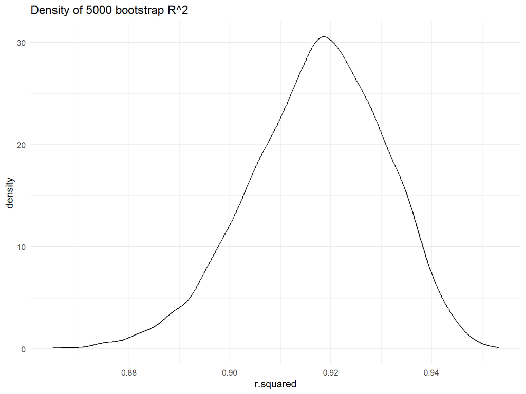

```r
weather_target |>
  select(r.squared)|>
  ggplot(aes(x = r.squared))+
  geom_density()+
  labs(
    title = "Density of 5000 bootstrap R^2"
  )
```

The distribution of $\hat{r}_*^2$ is close to normal distribution with little left skewness. The mean of r.square is 0.9172741, indicating a relatively well performed fit.

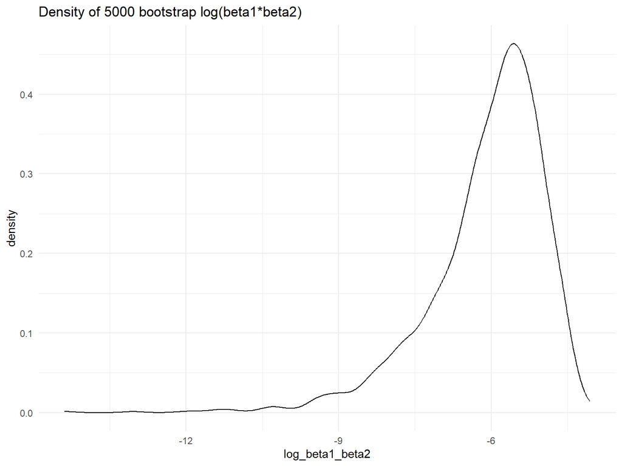

```r
weather_target |>
  select(log_beta1_beta2)|>
  ggplot(aes(x = log_beta1_beta2))+
  geom_density()+
  labs(
    title = "Density of 5000 bootstrap log(beta1*beta2)"
  )
```

The distribution of $log(\hat{\beta}_1*\hat{\beta}_2)$ is left skewed. The product of the coefficients of tmin and prcp is far below 1. We might consider if there is problems with the unit scale and the significance of the variable. The mean without NA is -6.0868668.

#### Construct CI for targeted value

```r
CI.rsquare <- c(
  CI.lower = weather_target |> pull(r.squared) |> quantile(.025),
  CI.upper = weather_target |> pull(r.squared) |> quantile(.975)
)

CI.log_beta <- c(
  CI.lower = weather_target |> pull(log_beta1_beta2) |> quantile(.025,na.rm = TRUE),
  CI.upper = weather_target |> pull(log_beta1_beta2) |> quantile(.975,na.rm = TRUE)
)
```

The CI for $\hat{r}_*^2$ is 0.8888529, 0.9405206, the relative large value of $\hat{r}_*^2$ indicating a good model fit.

The CI for $log(\hat{\beta}_1*\hat{\beta}_2)$ after filtering out NA is -8.987069, -4.5692038. The value is far below 0, indicating a small scale of the product. This may arise from the difference in unit scale or the low correlation of one predictor.

# Problem 3

#### Data explore and tidy

```r
nb_weight <- read_csv("./data/birthweight.csv")
```

Identify non-completed observations.

```r
complete <- nb_weight |> complete.cases()
nb_weight[!complete,]
```

```
## # A tibble: 0 × 20
## # ℹ 20 variables: babysex <dbl>, bhead <dbl>, blength <dbl>, bwt <dbl>,
## #   delwt <dbl>, fincome <dbl>, frace <dbl>, gaweeks <dbl>, malform <dbl>,
## #   menarche <dbl>, mheight <dbl>, momage <dbl>, mrace <dbl>, parity <dbl>,
## #   pnumlbw <dbl>, pnumsga <dbl>, ppbmi <dbl>, ppwt <dbl>, smoken <dbl>,
## #   wtgain <dbl>
```

It turns out that all cases are completed.

```r
nb_weight |> pull(pnumlbw)|>range()
```

```
## [1] 0 0
```

```r
nb_weight |> pull(pnumsga)|>range()
```

```
## [1] 0 0
```

However,`pnumlbw` and `pnumsga` variables only have 0 value, which contributes nothing to our dependent variables. Therefore, I might take these two variables out. Also,we turn categorical variables into factors

```r
weight_tidy <- nb_weight |>
  select(-pnumlbw,-pnumsga)|>
  mutate(
    babysex = factor(babysex, labels = c("male","female")),
    frace = case_match(frace,
      c(1) ~ "White",
      c(2) ~ "Black",
      c(3) ~ "Asian",
      c(4) ~ "Puerto Rican",
      c(8) ~ "Other",
      c(9) ~ "Unknown"
    ),
    mrace = case_when(
      mrace == 1 ~ "White",
      mrace == 2 ~ "Black",
      mrace == 3 ~ "Asian",
      mrace == 4 ~ "Puerto Rican",
      mrace == 8 ~ "Other"
    ),
    malform = case_match(malform,
      c(0) ~ "absent",
      c(1) ~ "present"
    )
  )
```

When further looking into data, I noticed something interesting.

```r
weight_tidy |> pull(frace) |> unique()
```

```
## [1] "White"        "Black"        "Asian"        "Puerto Rican" "Other"
```

```r
weight_tidy |> pull(mrace) |> unique()
```

```
## [1] "White"        "Black"        "Asian"        "Puerto Rican"
```

```r
## Test if the wtgain variable is the difference between delwt and ppwt
weight_test <- weight_tidy|>
  mutate(
    weight_change = delwt - ppwt,
    delta = weight_change - wtgain
  )|>
  select(delta)|>
  range()

## The range of the delta equals 0,indicating wtgain variable is the difference between delwt and ppwt
weight_test
```

```
## [1] 0 0
```

- First, the races of fathers only contains White, Black, Asian, Puerto Rican, Other, in total 5races.
- Second, the races of mothers only contains White, Black, Asian, Puerto Rican, in total 4races.
- Third, the variable `wtgain` is the difference between `delwt` and `ppwt`. This direct linear relationship can allow me to delete `wtgain` variables for linear regression purpose.

#### Fit my own model

Now generate the data for regression

```r
weight_reg <- weight_tidy|>
  select(-wtgain)
```

Get initial linear model

```r
model.0 <- lm(bwt ~ ., data = weight_reg)
```

Use AIC to select variables and read results

```r
model.AIC <- step(model.0)
```

```
## Start:  AIC=48717.83
## bwt ~ babysex + bhead + blength + delwt + fincome + frace + gaweeks +
##     malform + menarche + mheight + momage + mrace + parity +
##     ppbmi + ppwt + smoken
##
##            Df Sum of Sq       RSS   AIC
## - frace     4    124365 320848704 48712
## - malform   1      1419 320725757 48716
## - ppbmi     1      6346 320730684 48716
## - momage    1     28661 320752999 48716
## - mheight   1     66886 320791224 48717
## - menarche  1    111679 320836018 48717
## - ppwt      1    131132 320855470 48718
## <none>                  320724338 48718
## - fincome   1    193454 320917792 48718
## - parity    1    413584 321137922 48721
## - mrace     3    868321 321592659 48724
## - babysex   1    853796 321578134 48727
## - gaweeks   1   4611823 325336161 48778
## - smoken    1   5076393 325800732 48784
## - delwt     1   8008891 328733230 48823
## - blength   1 102050296 422774634 49915
## - bhead     1 106535716 427260054 49961
##
## Step:  AIC=48711.51
## bwt ~ babysex + bhead + blength + delwt + fincome + gaweeks +
##     malform + menarche + mheight + momage + mrace + parity +
##     ppbmi + ppwt + smoken
##
##            Df Sum of Sq       RSS   AIC
## - malform   1      1447 320850151 48710
## - ppbmi     1      6975 320855679 48710
## - momage    1     28379 320877083 48710
## - mheight   1     69502 320918206 48710
## - menarche  1    115708 320964411 48711
## - ppwt      1    133961 320982665 48711
## <none>                  320848704 48712
## - fincome   1    194405 321043108 48712
## - parity    1    414687 321263390 48715
## - babysex   1    852133 321700837 48721
```

[output cut: 70 more lines]

```
##     mheight + mrace + parity + ppwt + smoken
##
##           Df Sum of Sq       RSS   AIC
## <none>                 320986412 48705
## - fincome  1    245637 321232048 48707
## - parity   1    422770 321409181 48709
## - babysex  1    846134 321832545 48715
## - mheight  1   1012240 321998651 48717
## - ppwt     1   2907049 323893461 48743
## - gaweeks  1   4662501 325648912 48766
## - smoken   1   5073849 326060260 48771
## - delwt    1   8137459 329123871 48812
## - mrace    3  14683609 335670021 48894
## - blength  1 102191779 423178191 49903
## - bhead    1 106779754 427766166 49950
```

```r
summary(model.AIC)
```

```
##
## Call:
## lm(formula = bwt ~ babysex + bhead + blength + delwt + fincome +
##     gaweeks + mheight + mrace + parity + ppwt + smoken, data = weight_reg)
##
## Residuals:
##      Min       1Q   Median       3Q      Max
## -1097.18  -185.52    -3.39   174.14  2353.44
##
## Coefficients:
##                     Estimate Std. Error t value Pr(>|t|)
## (Intercept)       -6173.7087   142.5122 -43.321  < 2e-16 ***
## babysexfemale        28.5580     8.4549   3.378 0.000737 ***
## bhead               130.7770     3.4466  37.944  < 2e-16 ***
## blength              74.9471     2.0190  37.120  < 2e-16 ***
## delwt                 4.1067     0.3921  10.475  < 2e-16 ***
## fincome               0.3180     0.1747   1.820 0.068844 .
## gaweeks              11.5925     1.4621   7.929 2.79e-15 ***
## mheight               6.5940     1.7849   3.694 0.000223 ***
## mraceBlack          -63.9057    42.3663  -1.508 0.131523
## mracePuerto Rican   -25.7914    45.3502  -0.569 0.569578
## mraceWhite           74.8868    42.3146   1.770 0.076837 .
## parity               96.3047    40.3362   2.388 0.017004 *
## ppwt                 -2.6756     0.4274  -6.261 4.20e-10 ***
## smoken               -4.8434     0.5856  -8.271  < 2e-16 ***
## ---
## Signif. codes:  0 '***' 0.001 '**' 0.01 '*' 0.05 '.' 0.1 ' ' 1
##
## Residual standard error: 272.3 on 4328 degrees of freedom
## Multiple R-squared:  0.7181, Adjusted R-squared:  0.7173
## F-statistic: 848.1 on 13 and 4328 DF,  p-value: < 2.2e-16
```

Then make plot of residuals and fitted values

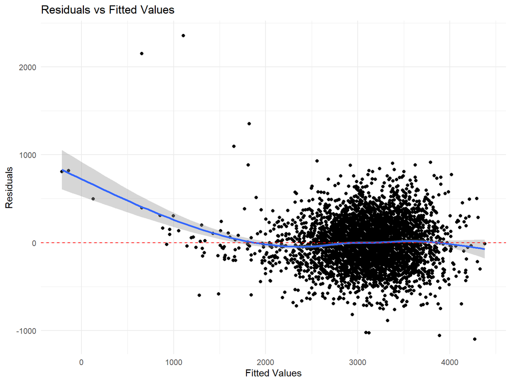

```r
weight_predict <- weight_reg |>
  add_residuals(model.AIC)|>
  add_predictions(model.AIC)

weight_predict |>
  ggplot(aes(x = pred, y = resid))+
  geom_point()+
  geom_smooth()+
  geom_hline(yintercept = 0, linetype = "dashed", color = "red") +
  labs(
    title = "Residuals vs Fitted Values",
    x = "Fitted Values",
    y = "Residuals")
```

We can see that the residuals and fitted values have correlation when fitted values are relatively small. The residuals has no significant patterns when the fitted values are around between 2000 to 4000. But overall the residuals are too big.This may be due to the insignificant races variables of the models.

#### Use cross validation to compare other two models

Then fit other two models

```r
model.1 <- lm(bwt ~ blength + gaweeks, data = weight_reg)
model.2 <- lm(bwt ~ bhead * blength * babysex, data = weight_reg)
summary(model.1)
```

```
##
## Call:
## lm(formula = bwt ~ blength + gaweeks, data = weight_reg)
##
## Residuals:
##     Min      1Q  Median      3Q     Max
## -1709.6  -215.4   -11.4   208.2  4188.8
##
## Coefficients:
##              Estimate Std. Error t value Pr(>|t|)
## (Intercept) -4347.667     97.958  -44.38   <2e-16 ***
## blength       128.556      1.990   64.60   <2e-16 ***
## gaweeks        27.047      1.718   15.74   <2e-16 ***
## ---
## Signif. codes:  0 '***' 0.001 '**' 0.01 '*' 0.05 '.' 0.1 ' ' 1
##
## Residual standard error: 333.2 on 4339 degrees of freedom
## Multiple R-squared:  0.5769, Adjusted R-squared:  0.5767
## F-statistic:  2958 on 2 and 4339 DF,  p-value: < 2.2e-16
```

```r
summary(model.2)
```

```
##
## Call:
## lm(formula = bwt ~ bhead * blength * babysex, data = weight_reg)
##
## Residuals:
##      Min       1Q   Median       3Q      Max
## -1132.99  -190.42   -10.33   178.63  2617.96
##
## Coefficients:
##                               Estimate Std. Error t value Pr(>|t|)
## (Intercept)                 -7176.8170  1264.8397  -5.674 1.49e-08 ***
## bhead                         181.7956    38.0542   4.777 1.84e-06 ***
## blength                       102.1269    26.2118   3.896 9.92e-05 ***
## babysexfemale                6374.8684  1677.7669   3.800 0.000147 ***
## bhead:blength                  -0.5536     0.7802  -0.710 0.478012
## bhead:babysexfemale          -198.3932    51.0917  -3.883 0.000105 ***
## blength:babysexfemale        -123.7729    35.1185  -3.524 0.000429 ***
## bhead:blength:babysexfemale     3.8781     1.0566   3.670 0.000245 ***
## ---
## Signif. codes:  0 '***' 0.001 '**' 0.01 '*' 0.05 '.' 0.1 ' ' 1
##
## Residual standard error: 287.7 on 4334 degrees of freedom
## Multiple R-squared:  0.6849, Adjusted R-squared:  0.6844
## F-statistic:  1346 on 7 and 4334 DF,  p-value: < 2.2e-16
```

Almost all the variables in these two models are significant, except the `bhead` and `blength` interaction part.

Now use cross validation to compare these three models

```r
cv_weight <- weight_reg|>
  crossv_mc(n = 100)|>
  mutate(
    train = map(train, as.tibble),
    test = map(test, as.tibble)
  )

## calculate rmse for each model

cv_model <- cv_weight|>
  mutate(
    model.AIC = map(train, \(df) lm(bwt ~ babysex + bhead + blength + delwt + fincome +gaweeks + mheight +  mrace + parity + ppwt + smoken,data = df)),
    model.1 = map(train, \(df) lm(bwt ~ blength + gaweeks, data = df)),
    model.2 = map(train, \(df) lm(bwt ~ bhead * blength * babysex, data = df))
    )|>
  mutate(
    rmse_aic = map2_dbl(model.AIC, test, \(mod,df) rmse(model = mod,data = df)),
    rmse_1 = map2_dbl(model.1, test, \(mod,df) rmse(model = mod,data = df)),
    rmse_2 = map2_dbl(model.2, test, \(mod,df) rmse(model = mod,data = df))
  )
```

After getting the RMSE of each model, then plot the violin plot to view the distribution of RMSE

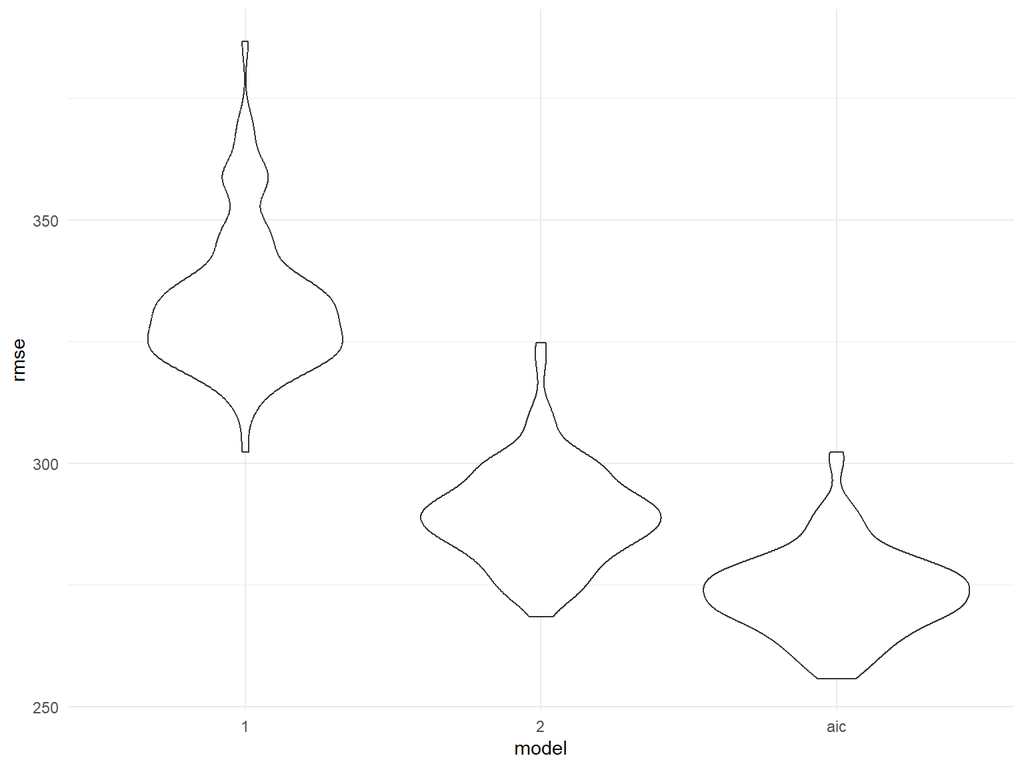

```r
cv_model |>
  select(starts_with("rmse"))|>
  pivot_longer(
    everything(),
    names_to = "model",
    values_to = "rmse",
    names_prefix = "rmse_"
  )|>
  ggplot(aes(x = model, y = rmse ))+
  geom_violin()
```

According to cross validation. It turns out that the model chosen form AIC has the average lowest RMSE compared to the two given models. Also, the RSME distribution of the AIC model under cross validation is also more concentrated.

Therefore,based on the outcome of cross validation, one might chose the model based on AIC.